# Multi Model 2.2

# Model 2.2: Sample-Level Prediction of COVID Deterioration

This model predicts future COVID deterioration from the metabolomic and clinical profile available at a single sample/presentation.

Multiple samples from the same patient are allowed as separate rows because each sample represents a separate clinical presentation. To prevent patient-level leakage, grouped cross-validation is used so all samples from the same patient stay in the same fold.

```r
library(reticulate)

py_require(c(
  "pandas",
  "numpy",
  "matplotlib",
  "seaborn",
  "scikit-learn",
  "xgboost",
  "joblib"
))
```

```python
# ============================================================
# SETUP
# ============================================================

import os
import hashlib
import joblib
import warnings

import numpy as np
import pandas as pd
import matplotlib.pyplot as plt
import seaborn as sns

warnings.filterwarnings("ignore")

from sklearn.model_selection import GroupKFold, GridSearchCV, cross_validate, cross_val_predict
from sklearn.impute import SimpleImputer
from sklearn.preprocessing import StandardScaler
from sklearn.pipeline import Pipeline
from sklearn.feature_selection import SelectFromModel

from sklearn.linear_model import LogisticRegression
from sklearn.ensemble import ExtraTreesClassifier
from sklearn.naive_bayes import GaussianNB
from sklearn.neural_network import MLPClassifier
from sklearn.svm import SVC
from xgboost import XGBClassifier

from sklearn.metrics import (
    classification_report,
    ConfusionMatrixDisplay,
    roc_curve,
    roc_auc_score,
    precision_recall_curve,
    average_precision_score,
    f1_score,
    balanced_accuracy_score,
    precision_score,
    recall_score
)

RANDOM_STATE = 42

CACHE_VERSION = "model_2_2"
CACHE_DIR = "cached_model_2_2"
os.makedirs(CACHE_DIR, exist_ok=True)

sns.set_theme(style="whitegrid")
```

# Load Data

```python
# ============================================================
# LOAD DATA
# ============================================================

df = pd.read_csv("model2dataset.csv")

df = df.replace(["-", "None", ""], np.nan)

df["day_from_sample"] = pd.to_numeric(df["day_from_sample"], errors="coerce")

df["time_from_symptom_onset_to_icu_days"] = pd.to_numeric(
    df["time_from_symptom_onset_to_icu_days"],
    errors="coerce"
)

df["x30_day_mortality"] = pd.to_numeric(
    df["x30_day_mortality"],
    errors="coerce"
).fillna(0)

df = df.drop(columns=[c for c in ["F1_X", "F2_X", "F3_X", "F4_X"] if c in df.columns])

print("Raw data shape:", df.shape)
```

```
Raw data shape: (700, 768)
```

```python
print("Unique patients:", df["patient_id"].nunique())
```

```
Unique patients: 339
```

# Create Sample-Level Future Deterioration Target

```python
# ============================================================
# SAMPLE-LEVEL TARGET
# ============================================================

df["sample_day"] = df["day_from_sample"]

def make_sample_target(row):
    icu_time = row["time_from_symptom_onset_to_icu_days"]
    sample_day = row["sample_day"]
    death_30 = row["x30_day_mortality"]

    if pd.isna(sample_day):
        return np.nan

    if death_30 == 1:
        return "deteriorating"

    if pd.notna(icu_time) and icu_time > sample_day:
        return "deteriorating"

    if pd.notna(icu_time) and icu_time <= sample_day:
        return np.nan

    return "stable"

df["deterioration_binary"] = df.apply(make_sample_target, axis=1)

df_model = df.dropna(subset=["deterioration_binary", "patient_id"]).copy()

print("Sample-level target counts:")
```

```
Sample-level target counts:
```

```python
print(df_model["deterioration_binary"].value_counts())
```

```
deterioration_binary
stable           353
deteriorating    240
Name: count, dtype: int64
```

```python
print("\nPatients retained:")
```

```
Patients retained:
```

```python
print(df_model["patient_id"].nunique())
```

```
339
```

# Define Candidate Predictor Groups

```python
# ============================================================
# DEFINE CANDIDATE PREDICTOR GROUPS
# ============================================================

# This is NOT final feature selection.
# This only defines the candidate feature pool using dataset structure and clinical domain variables.
# Actual feature selection happens later inside the cross-validation pipeline.

metabolite_cols = [
    c for c in df_model.columns
    if c.startswith(("F1_", "F2_", "F3_", "F4_"))
]

clinical_candidate_names = {
    "sex",
    "bmi",
    "age",
    "age_at_symptom_onset_years",
    "crp",
    "d_dimer",
    "neutrophil_percent",
    "co2",
    "neutrophil_absolute",
    "lymphocyte_absolute",
    "lymphocyte_percent",
    "il1b",
    "il10",
    "il6",
    "rantes",
    "mip1a",
    "gmcsf",
    "mcp1",
    "il15",
    "hgf",
    "vegf",
    "il1ra",
    "il2r",
    "mig",
    "il8"
}

clinical_cols = [
    c for c in df_model.columns
    if c.lower() in clinical_candidate_names
]

time_cols = ["sample_day"]

feature_cols = clinical_cols + time_cols + metabolite_cols

print("Metabolite features:", len(metabolite_cols))
```

```
Metabolite features: 707
```

```python
print("Clinical features:", len(clinical_cols))
```

```
Clinical features: 25
```

```python
print("Time features:", len(time_cols))
```

```
Time features: 1
```

```python
print("Total candidate predictors:", len(feature_cols))
```

```
Total candidate predictors: 733
```

# Clean Model Dataset

```python
# ============================================================
# CLEAN MODEL DATA
# ============================================================

target_col = "deterioration_binary"

model_df = df_model[["patient_id", target_col] + feature_cols].copy()

if "sex" in model_df.columns:
    model_df["sex"] = model_df["sex"].map({
        "Male": 1,
        "Female": 0,
        "male": 1,
        "female": 0,
        "M": 1,
        "F": 0
    })

for col in model_df.columns:
    if col not in ["patient_id", target_col]:
        model_df[col] = pd.to_numeric(model_df[col], errors="coerce")

feature_cols = [c for c in model_df.columns if c not in ["patient_id", target_col]]

missing_rate = model_df[feature_cols].isna().mean()
drop_missing = missing_rate[missing_rate > 0.50].index.tolist()

model_df = model_df.drop(columns=drop_missing)

feature_cols = [c for c in model_df.columns if c not in ["patient_id", target_col]]

constant_cols = [
    c for c in feature_cols
    if model_df[c].nunique(dropna=True) <= 1
]

model_df = model_df.drop(columns=constant_cols)

print("Final model dataframe shape:", model_df.shape)
```

```
Final model dataframe shape: (593, 735)
```

```python
print("Dropped high-missing features:", len(drop_missing))
```

```
Dropped high-missing features: 0
```

```python
print("Dropped constant features:", len(constant_cols))
```

```
Dropped constant features: 0
```

```python
print("\nFinal class counts:")
```

```
Final class counts:
```

```python
print(model_df[target_col].value_counts())
```

```
deterioration_binary
stable           353
deteriorating    240
Name: count, dtype: int64
```

```python
print("\nFinal unique patients:")
```

```
Final unique patients:
```

```python
print(model_df["patient_id"].nunique())
```

```
339
```

# Prepare Modelling Objects

```python
# ============================================================
# PREPARE X, y, GROUPS
# ============================================================

X = model_df.drop(columns=["patient_id", target_col])
X.columns = X.columns.astype(str)

y_raw = model_df[target_col].astype(str)
groups = model_df["patient_id"].astype(str)

# Important:
# 0 = stable
# 1 = deteriorating
# This keeps probability thresholds intuitive.
y = (y_raw == "deteriorating").astype(int).to_numpy()

positive_class = 1
negative_class = 0

target_names = ["stable", "deteriorating"]

n_positive = np.sum(y == positive_class)
n_negative = np.sum(y == negative_class)

scale_pos_weight = n_negative / n_positive

print("Class mapping:")
```

```
Class mapping:
```

```python
print("stable -> 0")
```

```
stable -> 0
```

```python
print("deteriorating -> 1")
```

```
deteriorating -> 1
```

```python
print("\nSamples:", X.shape[0])
```

```
Samples: 593
```

```python
print("Predictors:", X.shape[1])
```

```
Predictors: 733
```

```python
print("Unique patient groups:", groups.nunique())
```

```
Unique patient groups: 339
```

```python
print("\nClass proportions:")
```

```
Class proportions:
```

```python
print(y_raw.value_counts(normalize=True))
```

```
deterioration_binary
stable           0.595278
deteriorating    0.404722
Name: proportion, dtype: float64
```

```python
print("\nXGBoost scale_pos_weight:", round(scale_pos_weight, 3))
```

```
XGBoost scale_pos_weight: 1.471
```

# Class Distribution Plot

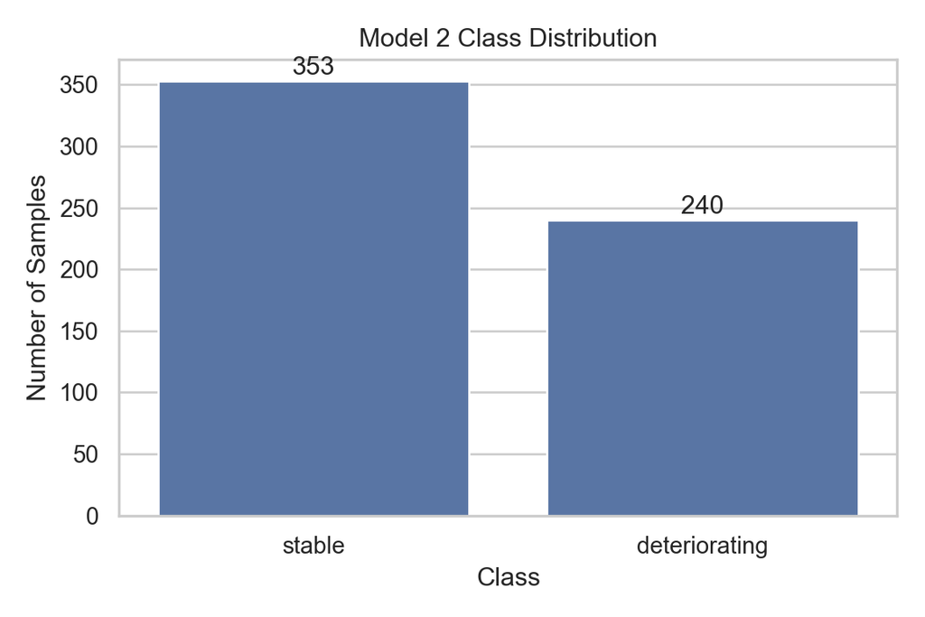

```python
# ============================================================
# CLASS DISTRIBUTION PLOT
# ============================================================

class_counts = y_raw.value_counts().reindex(["stable", "deteriorating"])

plt.figure(figsize=(6, 4))
sns.barplot(x=class_counts.index, y=class_counts.values)

plt.title("Model 2 Class Distribution")
plt.xlabel("Class")
plt.ylabel("Number of Samples")

for i, value in enumerate(class_counts.values):
    plt.text(i, value + 5, str(value), ha="center")

plt.tight_layout()
plt.show()
```

# Define Cache Key

```python
# ============================================================
# CACHE KEY
# ============================================================

cache_string = (
    CACHE_VERSION
    + str(X.shape)
    + str(list(X.columns))
    + str(pd.Series(y).value_counts().to_dict())
)

cache_key = hashlib.md5(cache_string.encode()).hexdigest()[:10]

print("Cache key:", cache_key)
```

```
Cache key: c0c5daaa3d
```

# Feature Selection Object

```python
df_features = pd.read_csv("metabolite_selections.csv")
model2_features = df_features.loc[
    df_features["Dataset_Availability"].isin(["Both", "Model 2 only"]),
    "Model_2_Name"
].dropna()
model2_features = model2_features[model2_features.isin(X.columns)].tolist()
X_2 = X[model2_features]
```

```python
# ============================================================
# FEATURE SELECTION OBJECT
# ============================================================

# Tree-based feature selection is placed inside each pipeline.
# This means feature selection is performed separately inside each CV training fold,
# preventing feature-selection leakage.

max_selected_features = min(100, X_2.shape[1])
et_selector = SelectFromModel(
    ExtraTreesClassifier(
        n_estimators=250,
        class_weight="balanced",
        random_state=RANDOM_STATE,
        max_features="sqrt",
        min_samples_leaf=2,
        n_jobs=1
    ),
    max_features=max_selected_features
)
```

# Define Six Models

```python
# ============================================================
# SIX MODEL DEFINITIONS + HYPERPARAMETER GRIDS
# ============================================================

model_specs = {

    "Extra Trees": {
        "pipeline": Pipeline([
            ("imputer", SimpleImputer(strategy="median")),
            ("feature_selection", et_selector),
            ("model", ExtraTreesClassifier(
                class_weight="balanced",
                random_state=RANDOM_STATE,
                n_jobs=1
            ))
        ]),
        "param_grid": {
            "feature_selection__max_features": [10, 20, 30, 40],
            "model__n_estimators": [250, 400],
            "model__max_features": ["sqrt", 0.3],
            "model__min_samples_leaf": [2, 3],
            "model__max_depth": [None, 8]
        }
    },

    "XGBoost": {
        "pipeline": Pipeline([
            ("imputer", SimpleImputer(strategy="median")),
            ("feature_selection", et_selector),
            ("model", XGBClassifier(
                objective="binary:logistic",
                eval_metric="logloss",
                random_state=RANDOM_STATE,
                n_jobs=1,
                scale_pos_weight=scale_pos_weight
            ))
        ]),
        "param_grid": {
            "model__n_estimators": [150, 250],
            "model__max_depth": [2, 3],
            "model__learning_rate": [0.03, 0.05],
            "model__subsample": [0.8, 1.0],
            "model__colsample_bytree": [0.8, 1.0]
        }
    },

    "Elastic Net Logistic Regression": {
        "pipeline": Pipeline([
            ("imputer", SimpleImputer(strategy="median")),
            ("scaler", StandardScaler()),
            ("feature_selection", et_selector),
            ("model", LogisticRegression(
                max_iter=5000,
                class_weight="balanced",
                penalty="elasticnet",
                solver="saga",
                random_state=RANDOM_STATE
            ))
        ]),
        "param_grid": {
            "feature_selection__max_features": [10, 20, 30, 40],
            "model__C": [0.05, 0.1, 0.5, 1.0],
            "model__l1_ratio": [0.25, 0.5, 0.75]
        }
    },

    "SVM RBF": {
        "pipeline": Pipeline([
            ("imputer", SimpleImputer(strategy="median")),
            ("scaler", StandardScaler()),
            ("feature_selection", et_selector),
            ("model", SVC(
                kernel="rbf",
                probability=True,
                class_weight="balanced",
                random_state=RANDOM_STATE
            ))
        ]),
        "param_grid": {
            "feature_selection__max_features": [10, 20, 30, 40],
            "model__C": [0.5, 1.0, 2.0],
            "model__gamma": ["scale", 0.01]
        }
    },

    "Gaussian Naive Bayes": {
        "pipeline": Pipeline([
            ("imputer", SimpleImputer(strategy="median")),
            ("scaler", StandardScaler()),
            ("feature_selection", et_selector),
            ("model", GaussianNB())
        ]),
        "param_grid": {
            "feature_selection__max_features": [10, 20, 30, 40],
            "model__var_smoothing": [1e-9, 1e-8, 1e-7, 1e-6]
        }
    },

    "MLP Neural Network": {
        "pipeline": Pipeline([
            ("imputer", SimpleImputer(strategy="median")),
            ("scaler", StandardScaler()),
            ("feature_selection", et_selector),
            ("model", MLPClassifier(
                activation="relu",
                solver="adam",
                early_stopping=True,
                validation_fraction=0.2,
                n_iter_no_change=30,
                max_iter=1500,
                random_state=RANDOM_STATE
            ))
        ]),
        "param_grid": {
            "feature_selection__max_features": [10, 20, 30, 40],
            "model__hidden_layer_sizes": [
                (16,),
                (32,),
                (32, 16),
                (64, 32),
                (64, 32, 16)
            ],
            "model__alpha": [0.001, 0.01, 0.05, 0.1],
            "model__learning_rate_init": [0.001, 0.0005, 0.0001],
            "model__batch_size": [16, 32, 64]
        }
    }
}

print("Models included:")
```

```
Models included:
```

```python
for model_name in model_specs.keys():
    print("-", model_name)
```

```
- Extra Trees
- XGBoost
- Elastic Net Logistic Regression
- SVM RBF
- Gaussian Naive Bayes
- MLP Neural Network
```

# Cached Hyperparameter Tuning

```python
# ============================================================
# CACHED GROUPED HYPERPARAMETER TUNING
# ============================================================

inner_cv = GroupKFold(n_splits=5)

tuned_results = {}
best_estimators = {}

for name, spec in model_specs.items():

    safe_name = name.replace(" ", "_").replace("/", "_")
    cache_path = os.path.join(CACHE_DIR, f"{cache_key}_{safe_name}_best_model.joblib")

    if os.path.exists(cache_path):
        print(f"\nLoading cached tuned model: {name}")

        cached = joblib.load(cache_path)

        best_estimators[name] = cached["best_estimator"]
        tuned_results[name] = cached["tuned_result"]

        continue

    print(f"\nTuning model: {name}")

    search = GridSearchCV(
        estimator=spec["pipeline"],
        param_grid=spec["param_grid"],
        scoring="f1_macro",
        cv=inner_cv,
        n_jobs=1,
        error_score="raise",
        refit=True
    )

    search.fit(X_2, y, groups=groups)

    tuned_results[name] = {
        "Best CV Macro F1": search.best_score_,
        "Best Params": search.best_params_
    }

    best_estimators[name] = search.best_estimator_

    joblib.dump({
        "best_estimator": search.best_estimator_,
        "tuned_result": tuned_results[name]
    }, cache_path)

    print("Best CV Macro F1:", round(search.best_score_, 3))
    print("Saved cache:", cache_path)
```

```
Loading cached tuned model: Extra Trees

Loading cached tuned model: XGBoost

Loading cached tuned model: Elastic Net Logistic Regression

Loading cached tuned model: SVM RBF

Loading cached tuned model: Gaussian Naive Bayes

Loading cached tuned model: MLP Neural Network
```

```python
tuned_results_df = pd.DataFrame(tuned_results).T.sort_values(
    "Best CV Macro F1",
    ascending=False
)

print("\nHyperparameter tuning summary:")
```

```
Hyperparameter tuning summary:
```

```python
print(tuned_results_df)
```

```
                                Best CV Macro F1                                        Best Params
MLP Neural Network                      0.726729  {'feature_selection__max_features': 10, 'model...
Elastic Net Logistic Regression         0.710151  {'feature_selection__max_features': 10, 'model...
XGBoost                                 0.709639  {'model__colsample_bytree': 0.8, 'model__learn...
SVM RBF                                 0.702947  {'feature_selection__max_features': 10, 'model...
Extra Trees                              0.68841  {'feature_selection__max_features': 10, 'model...
Gaussian Naive Bayes                    0.663966  {'feature_selection__max_features': 10, 'model...
```

# Final Grouped Cross-Validated Model Comparison

```python
# ============================================================
# FINAL GROUPED CV MODEL COMPARISON
# ============================================================

outer_cv = GroupKFold(n_splits=5)

final_results_cache = os.path.join(CACHE_DIR, f"{cache_key}_final_results.joblib")

if os.path.exists(final_results_cache):

    print("Loading cached final CV results.")
    final_results_df = joblib.load(final_results_cache)

else:

    final_results = {}

    for name, estimator in best_estimators.items():

        print("\nEvaluating tuned model:", name)

        scores = cross_validate(
            estimator,
            X_2,
            y,
            groups=groups,
            cv=outer_cv,
            scoring={
                "balanced_accuracy": "balanced_accuracy",
                "macro_f1": "f1_macro",
                "auroc": "roc_auc",
                "precision": "precision",
                "recall": "recall"
            },
            n_jobs=1,
            error_score="raise"
        )

        final_results[name] = {
            "Balanced Accuracy Mean": scores["test_balanced_accuracy"].mean(),
            "Balanced Accuracy SD": scores["test_balanced_accuracy"].std(),
            "Macro F1 Mean": scores["test_macro_f1"].mean(),
            "Macro F1 SD": scores["test_macro_f1"].std(),
            "AUROC Mean": scores["test_auroc"].mean(),
            "AUROC SD": scores["test_auroc"].std(),
            "Precision Mean": scores["test_precision"].mean(),
            "Precision SD": scores["test_precision"].std(),
            "Recall Mean": scores["test_recall"].mean(),
            "Recall SD": scores["test_recall"].std()
        }

    final_results_df = pd.DataFrame(final_results).T.sort_values(
        "Macro F1 Mean",
        ascending=False
    )

    joblib.dump(final_results_df, final_results_cache)
```

```
Loading cached final CV results.
```

```python
print("\nFinal grouped-CV model comparison:")
```

```
Final grouped-CV model comparison:
```

```python
print(final_results_df)
```

```
                                 Balanced Accuracy Mean  ...  Recall SD
MLP Neural Network                             0.727497  ...   0.142255
Elastic Net Logistic Regression                0.716455  ...   0.118804
XGBoost                                        0.715210  ...   0.108284
SVM RBF                                        0.711108  ...   0.119882
Extra Trees                                    0.694427  ...   0.134526
Gaussian Naive Bayes                           0.678024  ...   0.144718

[6 rows x 10 columns]
```

# Model Comparison Plots

[output not shown]

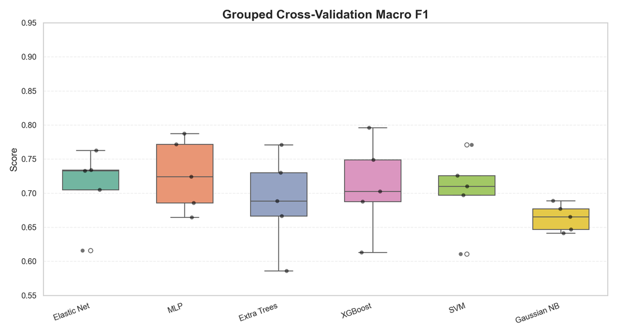

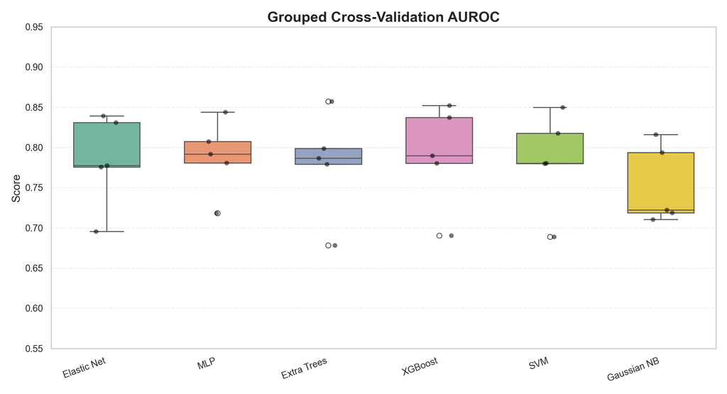

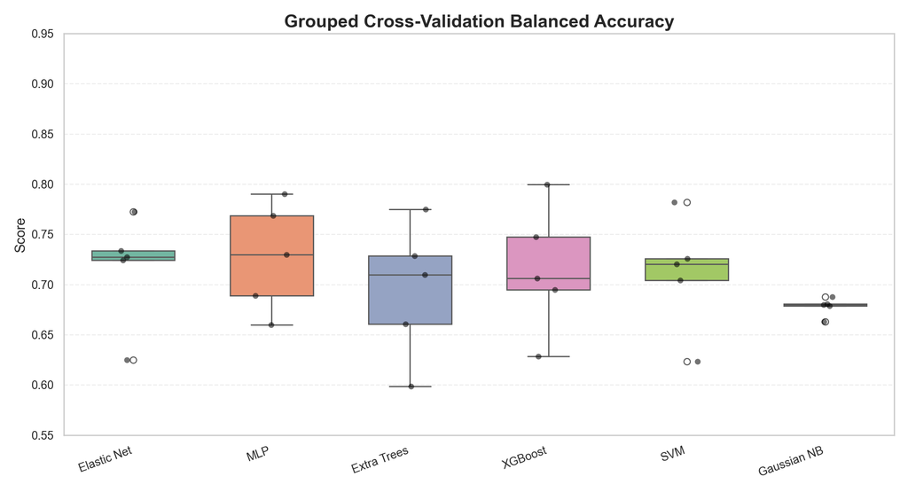

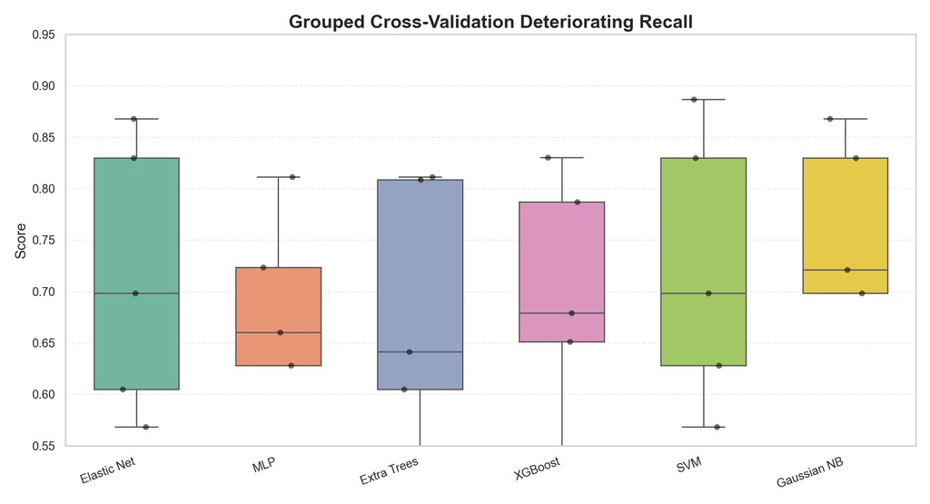

```python
# ============================================================
# FOUR SEPARATE MODEL PERFORMANCE BOXPLOTS
# ============================================================

fold_rows = []

for name, estimator in best_estimators.items():

    scores = cross_validate(
        estimator,
        X_2,
        y,
        groups=groups,
        cv=outer_cv,
        scoring={
            "Macro F1": "f1_macro",
            "AUROC": "roc_auc",
            "Balanced Accuracy": "balanced_accuracy",
            "Deteriorating Recall": "recall"
        },
        n_jobs=1,
        error_score="raise"
    )

    for i in range(5):
        fold_rows.append({
            "Model": name,
            "Macro F1": scores["test_Macro F1"][i],
            "AUROC": scores["test_AUROC"][i],
            "Balanced Accuracy": scores["test_Balanced Accuracy"][i],
            "Deteriorating Recall": scores["test_Deteriorating Recall"][i]
        })

fold_df = pd.DataFrame(fold_rows)

rename_map = {
    "Elastic Net Logistic Regression": "Elastic Net",
    "MLP Neural Network": "MLP",
    "Extra Trees": "Extra Trees",
    "XGBoost": "XGBoost",
    "SVM RBF": "SVM",
    "Gaussian Naive Bayes": "Gaussian NB"
}

fold_df["Model"] = fold_df["Model"].map(rename_map)

model_order = [
    "Elastic Net",
    "MLP",
    "Extra Trees",
    "XGBoost",
    "SVM",
    "Gaussian NB"
]

palette = sns.color_palette("Set2", n_colors=len(model_order))
palette_dict = dict(zip(model_order, palette))

metrics = [
    "Macro F1",
    "AUROC",
    "Balanced Accuracy",
    "Deteriorating Recall"
]

for metric in metrics:

    plt.figure(figsize=(12, 6.5))

    sns.boxplot(
        data=fold_df,
        x="Model",
        y=metric,
        order=model_order,
        palette=palette_dict,
        width=0.6,
        linewidth=1.2
    )

    sns.stripplot(
        data=fold_df,
        x="Model",
        y=metric,
        order=model_order,
        color="black",
        size=5.5,
        alpha=0.55,
        jitter=0.12
    )

    plt.title(f"Grouped Cross-Validation {metric}", fontsize=17, fontweight="bold")
    plt.xlabel("")
    plt.ylabel("Score", fontsize=13)
    plt.ylim(0.55, 0.95)

    plt.xticks(rotation=20, ha="right", fontsize=11)
    plt.yticks(fontsize=11)

    plt.grid(axis="y", linestyle="--", alpha=0.35)

    plt.tight_layout()
    plt.show()
```

# Select Best Model

```python
# ============================================================
# SELECT BEST MODEL
# ============================================================

best_model_name = final_results_df.index[0]
best_pipe = best_estimators[best_model_name]

print("Best final model:", best_model_name)
```

```
Best final model: MLP Neural Network
```

```python
print("\nBest tuned parameters:")
```

```
Best tuned parameters:
```

```python
print(tuned_results_df.loc[best_model_name, "Best Params"])
```

```
{'feature_selection__max_features': 10, 'model__alpha': 0.001, 'model__batch_size': 16, 'model__hidden_layer_sizes': (32,), 'model__learning_rate_init': 0.0001}
```

# Cross-Validated Predictions for Best Model

```python
# ============================================================
# CACHED CROSS-VALIDATED PREDICTIONS FOR BEST MODEL
# ============================================================

safe_best_name = best_model_name.replace(" ", "_").replace("/", "_")
pred_cache_path = os.path.join(CACHE_DIR, f"{cache_key}_{safe_best_name}_predictions.joblib")

if os.path.exists(pred_cache_path):

    print("Loading cached cross-validated predictions.")

    pred_cache = joblib.load(pred_cache_path)

    y_pred_cv = pred_cache["y_pred_cv"]
    y_proba_cv = pred_cache["y_proba_cv"]

else:

    print("Generating cross-validated predictions for best model.")

    y_pred_cv = cross_val_predict(
        best_pipe,
        X_2,
        y,
        groups=groups,
        cv=outer_cv,
        n_jobs=1,
        method="predict"
    )

    y_proba_cv = cross_val_predict(
        best_pipe,
        X_2,
        y,
        groups=groups,
        cv=outer_cv,
        n_jobs=1,
        method="predict_proba"
    )

    joblib.dump({
        "y_pred_cv": y_pred_cv,
        "y_proba_cv": y_proba_cv
    }, pred_cache_path)
```

```
Loading cached cross-validated predictions.
```

```python
positive_index = list(best_pipe.classes_).index(positive_class)
positive_probs = y_proba_cv[:, positive_index]
```

# Default Threshold Performance

```python
# ============================================================
# DEFAULT THRESHOLD PERFORMANCE
# ============================================================

print("Classification report using default threshold:")
```

```
Classification report using default threshold:
```

```python
print(classification_report(y, y_pred_cv, target_names=target_names))
```

```
               precision    recall  f1-score   support

       stable       0.77      0.81      0.79       353
deteriorating       0.70      0.65      0.68       240

     accuracy                           0.75       593
    macro avg       0.74      0.73      0.73       593
 weighted avg       0.74      0.75      0.75       593
```

```python
auc_value = roc_auc_score(y, positive_probs)
avg_precision = average_precision_score(y, positive_probs)

print("Grouped-CV AUROC:", round(auc_value, 3))
```

```
Grouped-CV AUROC: 0.781
```

```python
print("Grouped-CV Average Precision:", round(avg_precision, 3))
```

```
Grouped-CV Average Precision: 0.701
```

```python
ConfusionMatrixDisplay.from_predictions(
    y,
    y_pred_cv,
    display_labels=target_names,
    cmap="Blues"
)
```

```
<sklearn.metrics._plot.confusion_matrix.ConfusionMatrixDisplay object at 0x1489df3b0>
```

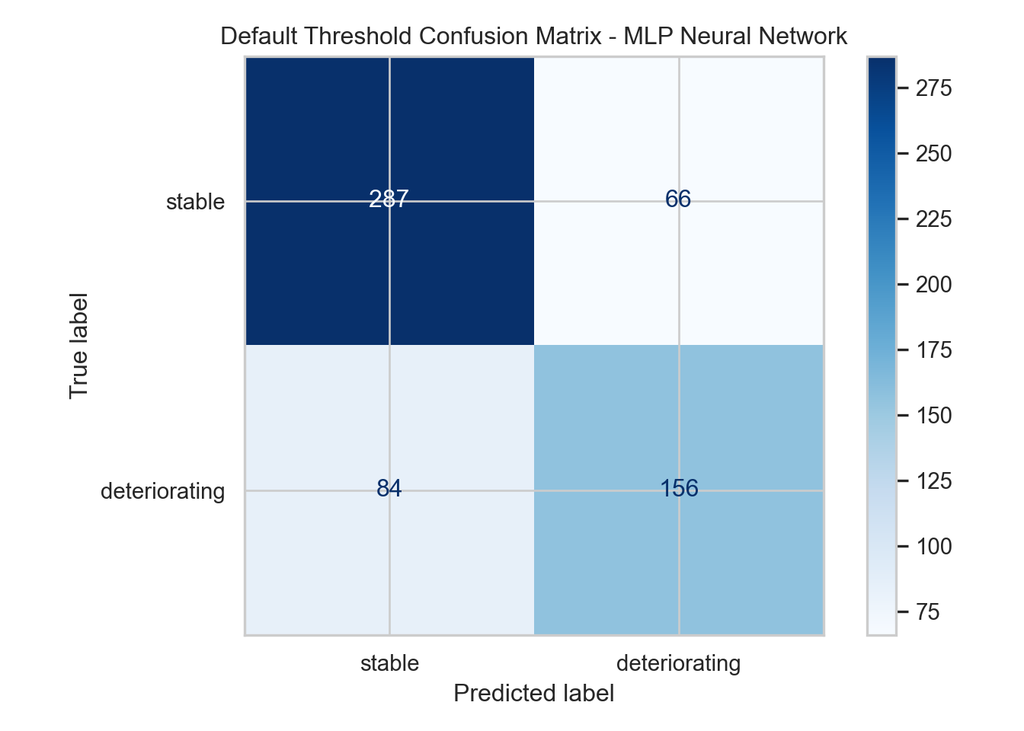

```python
plt.title(f"Default Threshold Confusion Matrix - {best_model_name}")
plt.tight_layout()
plt.show()
```

# Threshold Tuning

```python
# ============================================================
# THRESHOLD TUNING
# ============================================================

threshold_grid = np.arange(0.05, 0.96, 0.01)

threshold_rows = []

for threshold in threshold_grid:

    pred_labels = (positive_probs >= threshold).astype(int)

    threshold_rows.append({
        "threshold": threshold,
        "macro_f1": f1_score(y, pred_labels, average="macro"),
        "balanced_accuracy": balanced_accuracy_score(y, pred_labels),
        "deteriorating_precision": precision_score(y, pred_labels, zero_division=0),
        "deteriorating_recall": recall_score(y, pred_labels, zero_division=0),
        "stable_recall": recall_score(1 - y, 1 - pred_labels, zero_division=0)
    })

threshold_df = pd.DataFrame(threshold_rows)

best_threshold_row = threshold_df.sort_values("macro_f1", ascending=False).iloc[0]
best_threshold = best_threshold_row["threshold"]

print("Best threshold based on macro F1:")
```

```
Best threshold based on macro F1:
```

```python
print(best_threshold_row)
```

```
threshold                  0.490000
macro_f1                   0.739579
balanced_accuracy          0.738350
deteriorating_precision    0.698276
deteriorating_recall       0.675000
stable_recall              0.801700
Name: 44, dtype: float64
```

```python
threshold_pred_labels = (positive_probs >= best_threshold).astype(int)

print("\nClassification report using tuned threshold:")
```

```
Classification report using tuned threshold:
```

```python
print(classification_report(
    y,
    threshold_pred_labels,
    target_names=target_names
))
```

```
               precision    recall  f1-score   support

       stable       0.78      0.80      0.79       353
deteriorating       0.70      0.68      0.69       240

     accuracy                           0.75       593
    macro avg       0.74      0.74      0.74       593
 weighted avg       0.75      0.75      0.75       593
```

```python
ConfusionMatrixDisplay.from_predictions(
    y,
    threshold_pred_labels,
    display_labels=target_names,
    cmap="Blues"
)
```

```
<sklearn.metrics._plot.confusion_matrix.ConfusionMatrixDisplay object at 0x148b8bec0>
```

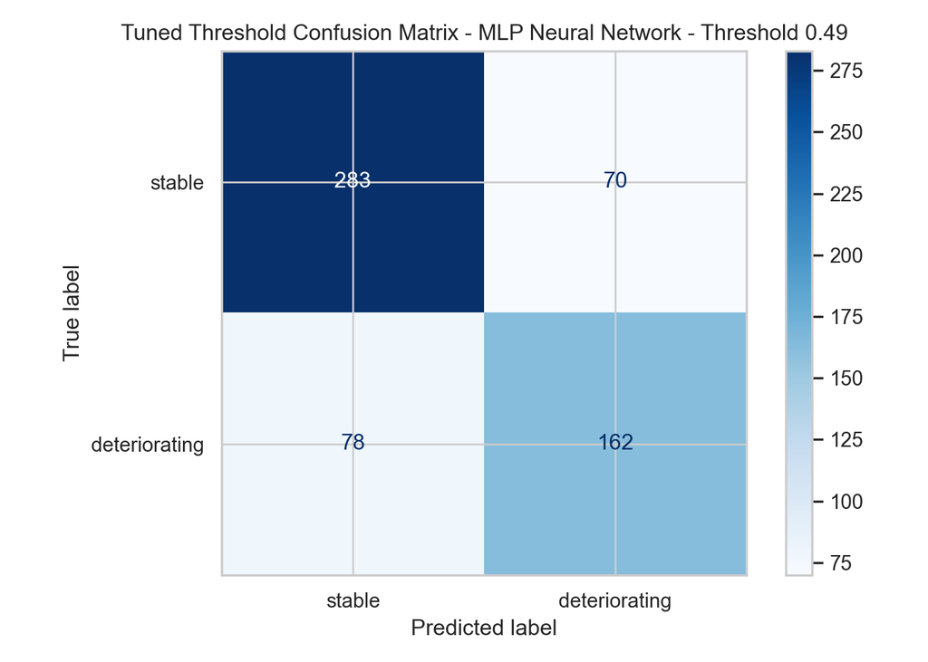

```python
plt.title(f"Tuned Threshold Confusion Matrix - {best_model_name} - Threshold {best_threshold:.2f}")
plt.tight_layout()
plt.show()
```

# Threshold Sensitivity Plot

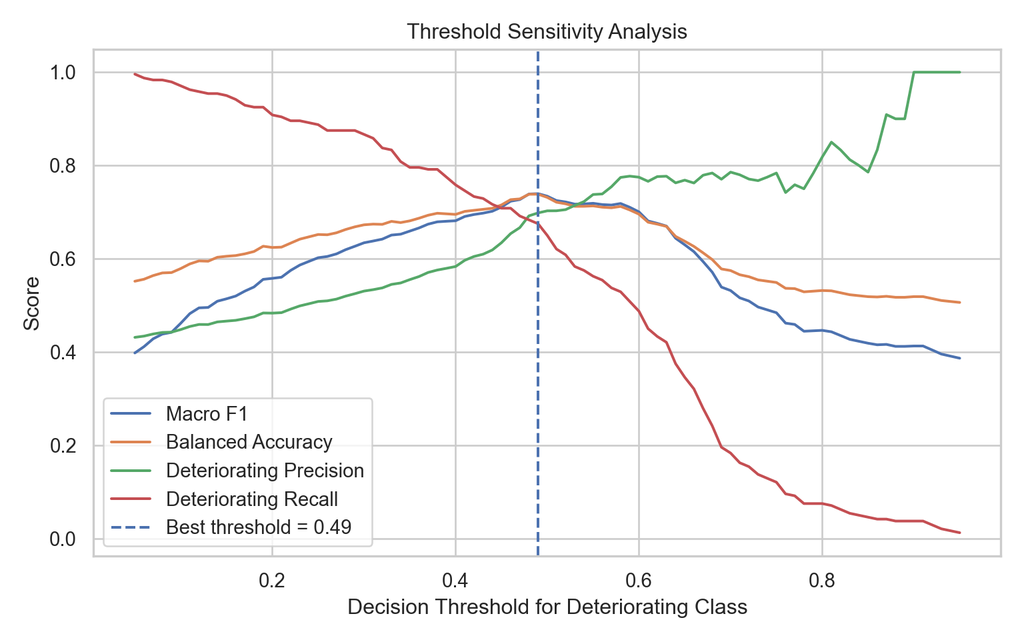

```python
# ============================================================
# THRESHOLD SENSITIVITY PLOT
# ============================================================

plt.figure(figsize=(8, 5))

plt.plot(threshold_df["threshold"], threshold_df["macro_f1"], label="Macro F1")
plt.plot(threshold_df["threshold"], threshold_df["balanced_accuracy"], label="Balanced Accuracy")
plt.plot(threshold_df["threshold"], threshold_df["deteriorating_precision"], label="Deteriorating Precision")
plt.plot(threshold_df["threshold"], threshold_df["deteriorating_recall"], label="Deteriorating Recall")

plt.axvline(best_threshold, linestyle="--", label=f"Best threshold = {best_threshold:.2f}")

plt.xlabel("Decision Threshold for Deteriorating Class")
plt.ylabel("Score")
plt.title("Threshold Sensitivity Analysis")
plt.legend()
plt.tight_layout()
plt.show()
```

# ROC Curve

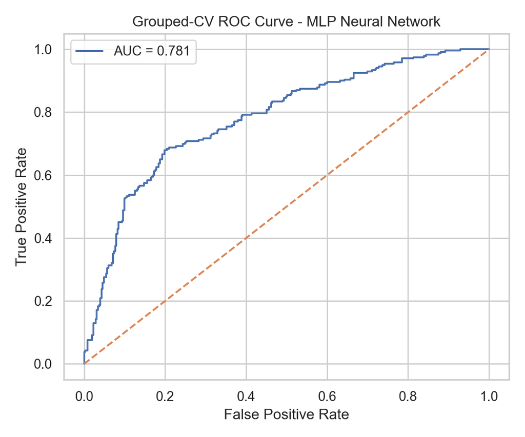

```python
# ============================================================
# ROC CURVE
# ============================================================

fpr, tpr, roc_thresholds = roc_curve(y, positive_probs)

plt.figure(figsize=(6, 5))

plt.plot(fpr, tpr, label=f"AUC = {auc_value:.3f}")
plt.plot([0, 1], [0, 1], linestyle="--")

plt.xlabel("False Positive Rate")
plt.ylabel("True Positive Rate")
plt.title(f"Grouped-CV ROC Curve - {best_model_name}")

plt.legend()
plt.tight_layout()
plt.show()
```

# Precision-Recall Curve

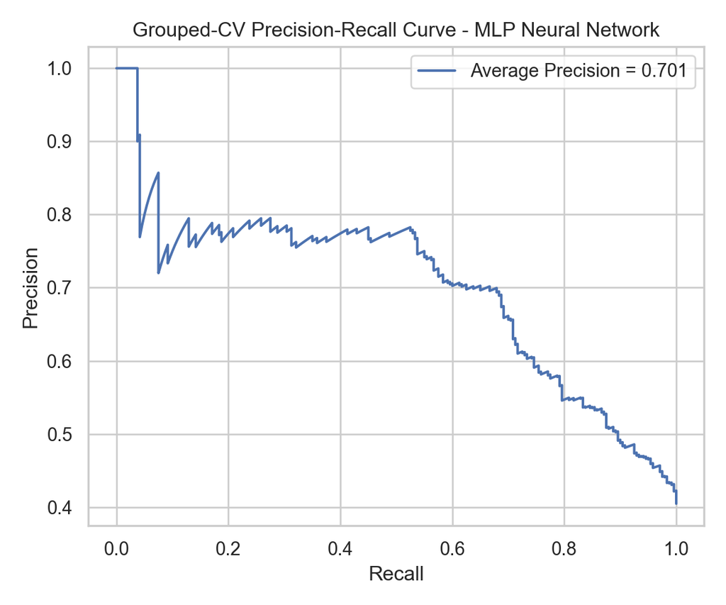

```python
# ============================================================
# PRECISION-RECALL CURVE
# ============================================================

precision, recall, pr_thresholds = precision_recall_curve(y, positive_probs)

plt.figure(figsize=(6, 5))

plt.plot(recall, precision, label=f"Average Precision = {avg_precision:.3f}")

plt.xlabel("Recall")
plt.ylabel("Precision")
plt.title(f"Grouped-CV Precision-Recall Curve - {best_model_name}")

plt.legend()
plt.tight_layout()
plt.show()
```

# Probability Distribution Plot

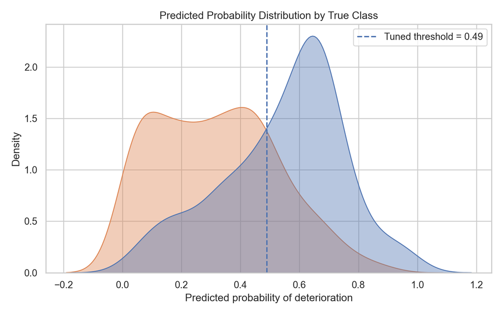

```python
# ============================================================
# PROBABILITY DISTRIBUTION PLOT
# ============================================================

prob_df = pd.DataFrame({
    "Predicted probability of deterioration": positive_probs,
    "True class": np.where(y == 1, "deteriorating", "stable")
})

plt.figure(figsize=(8, 5))

sns.kdeplot(
    data=prob_df,
    x="Predicted probability of deterioration",
    hue="True class",
    fill=True,
    common_norm=False,
    alpha=0.4
)

plt.axvline(best_threshold, linestyle="--", label=f"Tuned threshold = {best_threshold:.2f}")

plt.title("Predicted Probability Distribution by True Class")
plt.xlabel("Predicted probability of deterioration")
plt.ylabel("Density")
plt.legend()
plt.tight_layout()
plt.show()
```

# Feature Importance

```python
# ============================================================
# FEATURE IMPORTANCE
# ============================================================

best_pipe.fit(X_2, y)
```

```
Pipeline(steps=[('imputer', SimpleImputer(strategy='median')),
                ('scaler', StandardScaler()),
                ('feature_selection',
                 SelectFromModel(estimator=ExtraTreesClassifier(class_weight='balanced',
                                                                min_samples_leaf=2,
                                                                n_estimators=250,
                                                                n_jobs=1,
                                                                random_state=42),
                                 max_features=10)),
                ('model',
                 MLPClassifier(alpha=0.001, batch_size=16, early_stopping=True,
                               hidden_layer_sizes=(32,),
                               learning_rate_init=0.0001, max_iter=1500,
                               n_iter_no_change=30, random_state=42,
                               validation_fraction=0.2))])
```

```python
selector = best_pipe.named_steps["feature_selection"]
model = best_pipe.named_steps["model"]

selected_features = X_2.columns[selector.get_support()]

if hasattr(model, "feature_importances_"):
    importance_values = model.feature_importances_

elif hasattr(model, "coef_"):
    importance_values = np.mean(np.abs(model.coef_), axis=0)

else:
    importance_values = np.repeat(np.nan, len(selected_features))

importance_df = pd.DataFrame({
    "feature": selected_features,
    "importance": importance_values
}).sort_values("importance", ascending=False)

print("Top selected predictors:")
```

```
Top selected predictors:
```

```python
print(importance_df.head(30))
```

```
                      feature  importance
0          neutrophil_percent         NaN
1          lymphocyte_percent         NaN
2                     d_dimer         NaN
3                         age         NaN
4            F3_Phenylalanine         NaN
5                 F3_L.Serine         NaN
6             F3_D.Tryptophan         NaN
7  age_at_symptom_onset_years         NaN
```

[figure not shown]

```python
top_n = 15

plot_importance = importance_df.head(top_n).copy()

plot_importance["short_feature"] = [
    f[:38] + "..." if len(f) > 38 else f
    for f in plot_importance["feature"]
]

plt.figure(figsize=(10, 7))

plt.barh(
    plot_importance["short_feature"][::-1],
    plot_importance["importance"][::-1]
)

plt.xlabel("Importance")
plt.ylabel("")
plt.title(f"Top {top_n} Selected Predictors - {best_model_name}")

plt.tight_layout()
plt.show()
```

# Save Report Tables

```python
# ============================================================
# SAVE REPORT TABLES
# ============================================================

final_results_df.to_csv("model2_grouped_cv_results.csv")
tuned_results_df.to_csv("model2_tuned_hyperparameters.csv")
threshold_df.to_csv("model2_threshold_sensitivity.csv", index=False)
importance_df.to_csv("model2_feature_importance.csv", index=False)

print("Saved report tables:")
```

```
Saved report tables:
```

```python
print("- model2_grouped_cv_results.csv")
```

```
- model2_grouped_cv_results.csv
```

```python
print("- model2_tuned_hyperparameters.csv")
```

```
- model2_tuned_hyperparameters.csv
```

```python
print("- model2_threshold_sensitivity.csv")
```

```
- model2_threshold_sensitivity.csv
```

```python
print("- model2_feature_importance.csv")
```

```
- model2_feature_importance.csv
```

# Final Summary

```python
# ============================================================
# FINAL SUMMARY
# ============================================================

print("================ FINAL SUMMARY ================")
```

```
================ FINAL SUMMARY ================
```

```python
print("Aim: Predict future deterioration from one sample/presentation")
```

```
Aim: Predict future deterioration from one sample/presentation
```

```python
print("Leakage control: GroupKFold by patient_id")
```

```
Leakage control: GroupKFold by patient_id
```

```python
print("Samples:", X_2.shape[0])
```

```
Samples: 593
```

```python
print("Unique patients:", groups.nunique())
```

```
Unique patients: 339
```

```python
print("Predictors before selection:", X_2.shape[1])
```

```
Predictors before selection: 42
```

```python
print("Best model:", best_model_name)
```

```
Best model: MLP Neural Network
```

```python
print("Grouped-CV AUROC:", round(auc_value, 3))
```

```
Grouped-CV AUROC: 0.781
```

```python
print("Grouped-CV Average Precision:", round(avg_precision, 3))
```

```
Grouped-CV Average Precision: 0.701
```

```python
print("Default threshold Macro F1:", round(f1_score(y, y_pred_cv, average="macro"), 3))
```

```
Default threshold Macro F1: 0.734
```

```python
print("Best tuned threshold:", round(best_threshold, 2))
```

```
Best tuned threshold: 0.49
```

```python
print("Tuned threshold Macro F1:", round(f1_score(y, threshold_pred_labels, average="macro"), 3))
```

```
Tuned threshold Macro F1: 0.74
```

```python
print("\nBest model grouped CV performance:")
```

```
Best model grouped CV performance:
```

```python
print(final_results_df.loc[[best_model_name]].to_string())
```

```
                    Balanced Accuracy Mean  Balanced Accuracy SD  Macro F1 Mean  Macro F1 SD  AUROC Mean  AUROC SD  Precision Mean  Precision SD  Recall Mean  Recall SD
MLP Neural Network                0.727497              0.048377       0.726729     0.047418    0.788536  0.041167        0.711305      0.084318     0.641875   0.142255
```

```python
print("================================================")
```

# Interpretation Notes

The final model treats each blood sample as a separate clinical presentation, allowing multiple time points from the same patient to contribute separate observations. Grouped cross-validation was used so all samples from the same patient were kept in the same fold, preventing patient-level leakage.

The modelling workflow compares six distinct modelling paradigms: tree ensembles, gradient boosting, sparse linear modelling, kernel methods, probabilistic classification, and neural networks. Candidate clinical and metabolomic predictors are first defined using dataset structure and domain relevance, while final feature selection occurs inside the machine learning pipeline using tree-based selection within cross-validation.

The best model should be interpreted using AUROC, average precision, macro F1, balanced accuracy, and class-specific recall rather than accuracy alone, because the clinical problem involves imbalance and the deteriorating class is the class of interest.